# Rasters Part II: Analyzing and obtaining environmental rasters

Author

*Mason Stahl* (ENS-215)

Published

February 24, 2026

We are going to use the [`terra`](https://rspatial.github.io/terra/index.html) package today. The `terra` package is an R package for spatial analysis, with a primary focus on analyzing raster data.

Now, let’s load in the packages that we will use today.

**Note**

While we will be using the `terra` package throughout our analysis today we will not load in the **terra** package. Instead when we want to use a function from the `terra` package we will use the double-colon notation, for example, `terra::plot()` allows us to call the `plot()` function from the `terra` package. The reason we do this is because a number of the functions in the `terra` package has names that are identical to functions in the `tidyverse`packages. This can create conflicts/issues with your code and we can avoid these issues by calling `terra` functions using the double-colon notation.

```r
library(tidyverse)
library(tmap)
library(sf)
```

## Get elevation rasters in R

Land surface elevation (topographic) data is frequently useful/required for environmental and geoscience projects. Obtaining research-quality topographic data can be somewhat time consuming and cumbersome, however there are packages that allow you to seamlessly download this data directly into R. Today you’ll be introduced to the `elevatr` package, which allows you to seamlessly download elevation rasters for anywhere in the world. This package pulls data from several, research-quality datasets. More information on the package and the underlying datasets is [available here](https://cran.r-project.org/web/packages/elevatr/vignettes/introduction_to_elevatr.html)

First let’s load in the `elevatr` package. Let’s also load in the `tigris` package, which we’ve used in the past. The `tigris` package will be handy for getting borders (e.g., US state, US county), that we will use to define the area of interest for which we would like to download elevation rasters.

Note: If you haven’t already done so, then you will need to first install both the `elevatr` and the `tigris` packages.

```r
library(elevatr)
library(tigris)
```

Let’s get the county boundaries for NY state and then use `filter()` to get just Schenectady county.

```r
NY_counties <- counties(state = "NY",
                        cb = TRUE)
```

```r
county_schenectady <- NY_counties %>%
  filter(NAME == "Schenectady")
```

Now that we have the area of interest, let’s obtain the elevation raster for that area. We will use the `get_elev_raster()` function from the `elevatr` package. The first argument in the function is a sf object that represents our area of interest (i.e., Schenectady county). The second argument `z` species the resolution of the raster data that we would like to download. A value of 1 specifies the lowest resolution and a value of 14 is the highest resolution available. Note that downloading a very high resolution raster for a large area will take much longer (and be a much larger file size). The `clip` argument specifies if your want to clip the raster to the spatial object. By specifying `clip = "locations"` the elevation raster will be clipped to the boundaries of Schenectady county. FYI, when you run the code you will see a download progress bar in your console.

```r
raster_elev <- get_elev_raster(county_schenectady,
                               z = 12,
                               clip = "locations")
```

```
Mosaicing & Projecting
```

```
Clipping DEM to locations
```

```
Note: Elevation units are in meters.
```

Let’s quickly plot the data to confirm that we’ve downloaded what we expected.

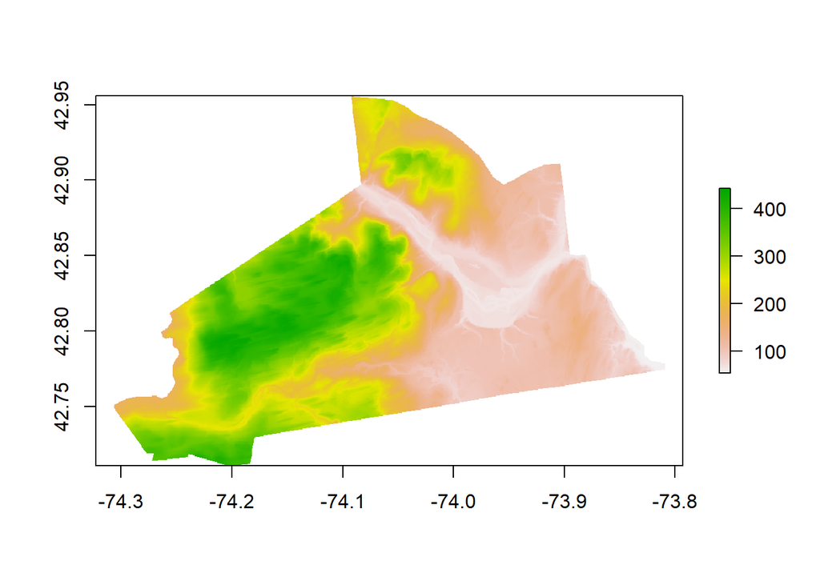

```r
terra::plot(raster_elev)
```

Just to highlight how the raster resolution makes a difference, below I am showing the raster for Schenectady County where `z = 6` (low resolution). You can see it has much less detail than the raster above where `z = 12` (high resolution).

**Low resolution**

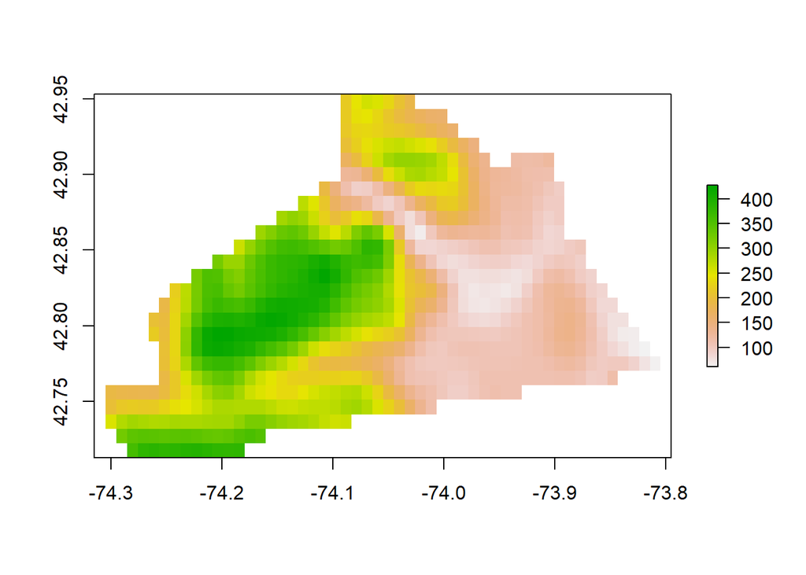

Pretty cool - we’ve quickly and seamlessly obtained raster elevation data for our area of interest. You can try to modify the code above to test out the `get_elev_raster()` function some more and to try it on different areas.

The `get_elev_raster()` can be used for any location around the world. To demonstrate this let’s obtain raster elevation data for Lesotho (country in southern Africa).

To obtain high resolution border data we will use the package `rnaturalearth`. This package let’s you easily download a range of spatial data into R. More info on the package can be found here. FYI, you will need to install `rnaturalearth` if you haven’t yet installed it.

```r
library(rnaturalearth)
```

You should also install the `rnaturalearthhires` package.

> To do this you will need to first run the following line of code **in your console**.

> `install.packages("remotes")`

> Then you should run the following line of code **in your console**.

> `remotes::install_github("ropensci/rnaturalearthhires")`

Now let’s download the country border for Lesotho

```r
borders_hires <- ne_countries(country = "Lesotho",
                              scale = "large",
                              returnclass = "sf")
```

Following the same approach as we did with Schenectady county, we will now get elevation data for the country of Lesotho

```r
raster_elev_lesotho <- get_elev_raster(borders_hires,
                                       z = 9,
                                       clip = "locations")
```

```
Mosaicing & Projecting
```

```
Clipping DEM to locations
```

```
Note: Elevation units are in meters.
```

Let’s use `tmap` to make a quick map of the topography of Lesotho

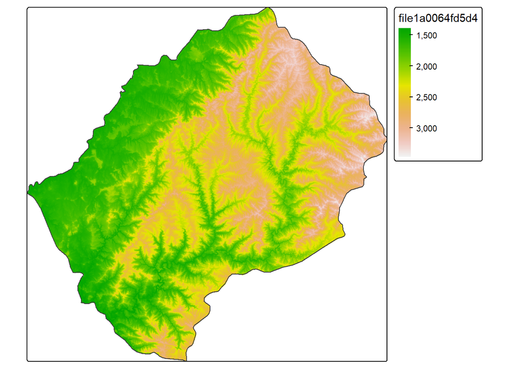

```r
raster_elev_lesotho %>%
  tm_shape() +
  tm_raster(col.scale = tm_scale_continuous(values = terrain.colors(n = 10))) +

  tm_shape(borders_hires) +
  tm_borders()
```

## Get climate rasters in R

In addition to elevation data, we frequently need gridded (raster) climatic/meteorological data for environmental projects. Once again, R comes to the rescue and allows you to seamlessly query and download a range of research-quality gridded climatic/meteorological datasets. One package that is particularly useful in this area is `climateR`. The `climateR` package gives you access to data from a host of datasets including gridMET (US meteorological data) and TerraClim (global meteorological data). Each of these datasets has their particular set of variables (e.g., precipitation, temperature, barometric pressure,…) and their particular characteristics (e.g., spatial and temporal resolution, underlying data used to generated the gridded data product). When conducting research you would want to be aware of these technical details and you would choose the best available data for your application. To learn more about the `climateR` package and the data it can query you can go to the [following website](https://mikejohnson51.github.io/climateR/), which provides a general overview.

Once you have the remotes package installed (which you should have done earlier in today’s lecture), you should then install the `climateR` package by running the following code **in your console**.

> `remotes::install_github("mikejohnson51/climateR")`

After the `climateR` package has been installed, you can load it in using the code below.

```r
library(climateR)
```

Let’s use the `ne_states()` function from the `rnaturalearth` package, which will allow us to download high-resolution borders for the US. You will likely need to install this package first.

```r
border_NY <- ne_states(country = "United States of America", returnclass = "sf")

border_NY <- border_NY %>%
  filter(name == "New York")
```

### gridMET data (US meteorological data)

gridMET is a gridded meteorological dataset for the United States. gridMET is a high-quality dataset that is widely used in climate and environmental research applications. More details on the data are [available here](https://www.climatologylab.org/gridmet.html).

Using the `climateR` package you can quickly and efficiently load gridMET data right into R. Let’s first see what variables are available for download.

```r
catalog %>%
  filter(id == "gridmet") %>%
  select(varname, units, description)
```

| varname | units | description |
| --- | --- | --- |
| precipitation_amount | mm | pr |
| daily_maximum_relative_humidity | % | rmax |
| daily_minimum_relative_humidity | % | rmin |
| daily_mean_specific_humidity | kg/kg | sph |
| daily_mean_shortwave_radiation_at_surface | W m-2 | srad |
| daily_mean_wind_direction | Degrees Clockwise from north | th |
| daily_minimum_temperature | K | tmmn |
| daily_maximum_temperature | K | tmmx |
| daily_mean_wind_speed | m/s | vs |
| daily_mean_burning_index_g | Unitless | bi |

[output cut: 56 more lines]

Let’s go ahead and download the gridded data for the daily minimum air temperature for the state of NY. The gridMET data is available at daily temporal resolution.

To download the data we will use the `climateR` package. Let’s just download one day of data (FYI, you can easily download multiple days if you want to). Since Feb 4th, 2023 was an extremely cold day in NY, let’s get data for that day.

to get gridMET data we use the aptly named `getGridMET()` function. The first argument (`AOI = border_NY`) specifies a spatial polygon (e.g., border) that defines the area over which to get the data. The second argument specifies the gridMET variable(s) to download. The third argument specifies the date for which to download data for. FYI, to download data over more than one day, you would add another argument that specifies the `endDate` to use.

```r
p <- getGridMET(AOI = border_NY,
             varname = c("tmmn"),
             startDate = "2023-02-04", verbose = T
             )
```

```
source:  http://thredds.northwestknowledge.net:8080/thredds/dodsC/agg...
varname(s):
   > daily_minimum_temperature [K] (tmmn)
==================================================
diminsions:  191, 111, 1 (names: lon,lat,day)
resolution:  0.042, 0.042, 1 days
extent:      -79.79, -71.83, 40.46, 45.09 (xmin, xmax, ymin, ymax)
crs:         +proj=longlat +a=6378137 +f=0.00335281066474748 +p...
time:        2023-02-04 to 2023-02-04
==================================================
values: 21,201 (vars*X*Y*T)
```

```r
p <- p$daily_minimum_temperature
```

Since the gridMET data is obtained as tiles (large rectangular area that covers your area of interest), we often want to crop and mask the data to keep just the pixels that fall within our specified area. Let’s go ahead and do this.

```r
p <- terra::crop(p, border_NY)

p <- terra::mask(p, border_NY)
```

```r
p
```

```
class       : SpatRaster
size        : 108, 189, 1  (nrow, ncol, nlyr)
resolution  : 0.04166669, 0.04166669  (x, y)
extent      : -79.74583, -71.87083, 40.50417, 45.00417  (xmin, xmax, ymin, ymax)
coord. ref. : +proj=longlat +ellps=WGS84 +no_defs
source(s)   : memory
name        : tmmn_2023-02-04
min value   :           234.8
max value   :           261.8
unit        :               K
time        : 2023-02-04 UTC
```

You can see above that the units of temperature are degrees Kelvin. To convert to degrees C we will simply need to subtract 273.15 from the raster.

```r
p <- p - 273.15
```

Now that we have our data and have cropped/masked it to our area of interest, let’s make a map of the data.

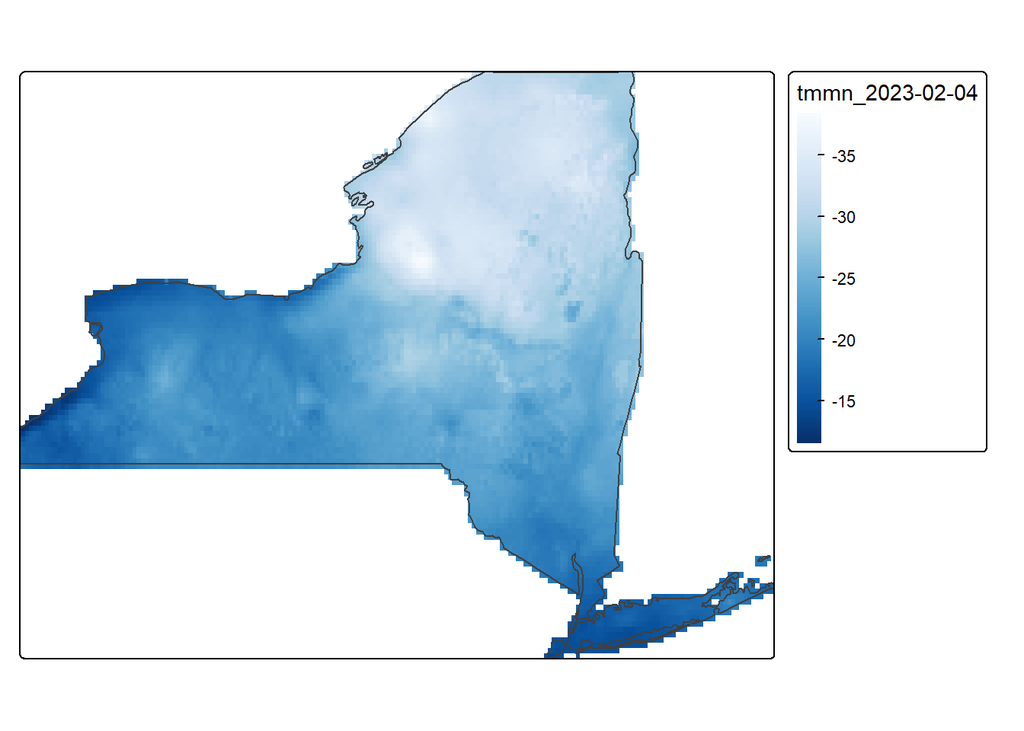

```r
p %>%
  tm_shape() +
  tm_raster(col.scale = tm_scale_continuous(values = "brewer.blues")) +
  #tm_raster(palette = "Blues", n = 10) +

  tm_shape(border_NY) +
  tm_borders()
```

### TerraClim (Global meteorological data)

gridMET provides excellent daily meteorological data for the US, however if we want gridded met data for outside of the US we will need to rely on another data product. TerraClim provides two sets of gridded climate data namely, climate normals and climate monthlies.

Climate normals are gridded monthly average values for a given time period (e.g., 1981-2010). Thus the January normal of precipitation would be a gridded raster of average precipitation where the average was taken across all of the Januaries between 1981-2010.

The climate monthlies are gridded monthly data for a given year-month. Thus you could obtain the gridded precipitation data for January 2020 (or February 2020, or March 1995,…).

Let’s go ahead and get the gridded climate monthlies of precipitation for the country of Switzerland.

First, we will use the `ne_countries()` function from the `rnaturalearth` package to get the border of the country of Switzerland.

```r
borders_hires <- rnaturalearth::ne_countries(country = "Switzerland",
                                             scale = "large",
                                             returnclass = "sf")
```

The variables available from the TerraClim normals are the following:

```r
catalog %>%
  filter(id == "terraclim") %>%
  select(varname, units, description)
```

| varname | units | description |
| --- | --- | --- |
| aet | mm | water_evaporation_amount |
| def | mm | water_potential_evaporation_amount_minus_water_evaporation_amount |
| PDSI | unitless | palmer_drought_severity_index |
| pet | mm | water_potential_evaporation_amount |
| ppt | mm | precipitation_amount |
| q | mm | runoff_amount |
| soil | mm | soil_moisture_content |
| srad | W/m^2 | downwelling_shortwave_flux_in_air |
| swe | mm | liquid_water_content_of_surface_snow |
| tmax | degC | air_temperature |

[output cut: 4 more lines]

Now we will use the `getTerraClim()` from `climateR` to get the TerraClim monthly precipitation data. The `AOI` specifies the spatial object that describes the area of interest. The `varname` argument specifies the variable download. The `startDate` argument specifies the start date for the time period of interest and the `endDate` specifies the end date for our period of interest

**Important**

The server that provides TerraClim data was out of service on 18-Feb-2026 (though seemed to be working again on 22-Feb-2026). It is not clear if this is a short-term issue and will be resolved shortly or if this may be a longer-term issue. We can try this code in class on 24-Feb-2026, however if it doesn’t work then we will skip it and get monthly precipitation data from the CHIRPS dataset.

```r
climate_raster <- getTerraClim(
  AOI = borders_hires,
  varname = "ppt",
  startDate = "2021-01-01",
  endDate = "2021-12-01",
  verbose = T,
  dryrun = FALSE
)
```

**Important**

If the TerraClim code above didn’t work, then run the code block directly below. If the `getTerraClim()` code above worked, then skip the code block directly below.

```r
## Run this code if the getTerraClim() code above did not work.

climate_raster <- getCHIRPS(
  AOI = borders_hires,
  #varname = "ppt",
  timeRes = "Monthly",
  startDate = "2021-01-01",
  endDate = "2021-12-01",
  verbose = T,
  dryrun = FALSE
  )
```

```
source:  https://coastwatch.pfeg.noaa.gov/erddap/griddap/chirps20Glob...
varname(s):
   > precip [mm/month] (Precipitation)
==================================================
diminsions:  91, 41, 12 (names: longitude,latitude,time)
resolution:  0.05, 0.05, 1 months
extent:      5.95, 10.5, 45.8, 47.85 (xmin, xmax, ymin, ymax)
crs:         +proj=longlat +a=6378137 +f=0.00335281066474748 +p...
time:        2021-01-01 to 2021-12-01
==================================================
values: 44,772 (vars*X*Y*T)
```

Since `climateR` returns the data as a list of rasters, we will run the following code to obtain the raster from the list object. This just makes the data easier to deal with in the following steps, as we now have `climate_raster` as a raster object.

If you were able to get the TerraClim data, then uncomment the first line of the code block below. If you got CHIRPS data, then uncomment the second line of code in the code block below.

```r
# climate_raster <- climate_raster$ppt
# climate_raster <- climate_raster$precip
```

Now let’s crop and mask the raster.

```r
climate_raster <- terra::crop(climate_raster, borders_hires)

climate_raster <- terra::mask(climate_raster, borders_hires)
```

And then make a map.

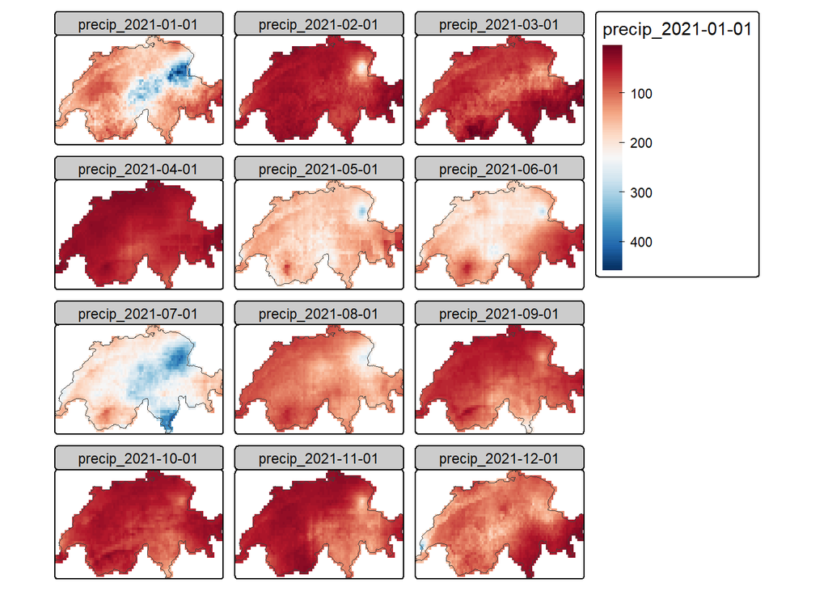

```r
climate_raster %>%
  tm_shape() +
  tm_raster(col.scale = tm_scale_continuous(values = "brewer.rd_bu"), col.free = F) +

  tm_shape(borders_hires) +
  tm_borders()
```

Pretty cool! We have a faceted map showing the monthly precipitation for the year 2021 for Switzerland. You could easily modify the above code to obtain precipitation (or other meteorological data) for a different area of interest.

```r
switzerland_tot_prcp <- sum(climate_raster)
```

Now let’s make a map to confirm that we did what we had expected to do. Note that within the `switzerland_tot_prcp` object, the default layer name is `sum`, and thus we need to refer to that layer in the code below.

```
── tmap v3 code detected ───────────────────────────────────────────────────────
```

[output not shown]

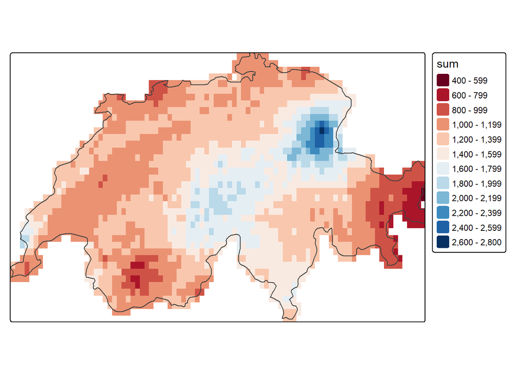

```r
switzerland_tot_prcp$sum %>%
  tm_shape() +
  tm_raster(palette = "RdBu", n = 10) +

  tm_shape(borders_hires) +
  tm_borders()
```

## Exercises

Explore the `elevatr` and `climateR` packages. Try to download additional variables for different areas of interest. Make some new/modified meteorological and/or topographic maps. Come up with some interesting questions that you can use these packages to help you answer.

## Additional rasters

We will see some additional topics in spatial and raster analysis in the coming lectures, though this is a large topic and we will just scratch the surface in this class. Let me know if you want to try something else but aren’t sure how to move forward. I can also point you to additional data. A great place to quickly find some interesting rasters is at [NASA Earth Observation website](https://neo.gsfc.nasa.gov/dataset_index.php). You can quickly view rasters and download data for preliminary analysis at this site. The site also provides information and links to the research quality versions of the data if you are interested (though for most initial analysis the data on the link I provide are sufficient).